# Homework

Jiaqi Wu

2020-12-19

## Homework-09.22

## Example1

Below are the scatter plots of Violent Crime Rates by US State:

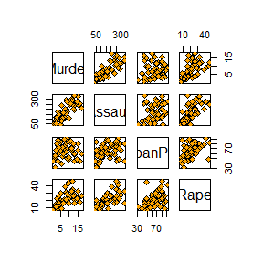

```r
pairs(USArrests, pch=23, bg='orange',
      cex.labels=1.5)
```

## Example2

Below is the head of the data:

```r
knitr::kable(head(USArrests))
```

|  | Murder | Assault | UrbanPop | Rape |
| --- | --- | --- | --- | --- |
| Alabama | 13.2 | 236 | 58 | 21.2 |
| Alaska | 10.0 | 263 | 48 | 44.5 |
| Arizona | 8.1 | 294 | 80 | 31.0 |
| Arkansas | 8.8 | 190 | 50 | 19.5 |
| California | 9.0 | 276 | 91 | 40.6 |
| Colorado | 7.9 | 204 | 78 | 38.7 |

## Example3

Here are a few facts about multiple linear regression:
$$Y_i = \beta_0 + \beta_1 X_{i1} + \dots + \beta_p X_{ip} + \varepsilon_i$$
$$\begin{aligned}
SSE(\beta_0, \dots, \beta_p) &= \sum_{i=1}^n\left(Y_i - \left(\beta_0 + \sum_{j=1}^p \beta_j \
X_{ij} \right) \right)^2 \\
&= \|Y - \widehat{Y}(\beta)\|^2
\end{aligned}$$
$$\widehat{\sigma}^2 = \frac{SSE}{n-p-1} \sim \sigma^2 \cdot \frac{\chi^2_{n-p-1}}{n-p\
-1}$$

## Homework-09.29

## Question1

The Pareto $(a, b)$ distribution has cdf
$$F(x)=1-\left(\frac{b}{x}\right)^{a}, \quad x \geq b>0, a>0.$$
Derive the probability inverse transformation $F^{-1}(U)$ and use the inverse transform method to simulate a random sample from the Pareto$(2, 2)$ distribution. Graph the density histogram of the sample with the Pareto $(2,2)$ density superimposed for comparison.

## Answer

If $X\sim Pareto(2, 2)$, then for $x>0$ the cdf of $X$ is $F_X(x)=1-\left(\frac{2}{x}\right)^{2}$. The inverse transformation is $F_X^{-1}(u)=\frac{2}{\sqrt{1-u}}$. Note $U$ and $1-U$ have the same distribution, we generate $X$ with $x= \frac{2}{\sqrt{u}}$.

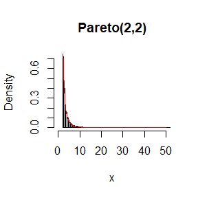

```r
set.seed(12345)
n <- 10000
u <- runif(n)
x <- 2/sqrt(u)
hist(x, prob=TRUE, main = 'Pareto(2,2)', xlim = c(0,50), breaks=500)
y <- seq(2, 50, .1)
lines(y, 8/(y^3),lwd = 1.5, col = "red")
```

We can see that the empirical and theoretical distributions approximately agree.

## Question2

The rescaled Epanechnikov kernel is a symmetric density function
$$f_{e}(x)=\frac{3}{4}\left(1-x^{2}\right), \quad|x| \leq 1.$$
Devroye and Györfi give the following algorithm for simulation from this distribution. Generate iid $U_{1}, U_{2}, U_{3} \sim$ Uniform $(-1,1) .$ If $\left|U_{3}\right| \geq$ $\left|U_{2}\right|$ and $\left|U_{3}\right| \geq\left|U_{1}\right|,$ deliver $U_{2} ;$ otherwise deliver $U_{3} .$ Write a function to generate random variates from $f_{e},$ and construct the histogram density estimate of a large simulated random sample.

## Answer

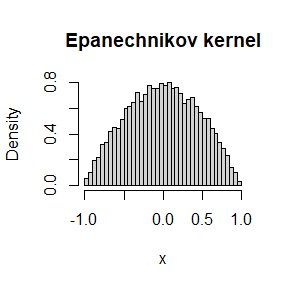

```r
repan <- function(n){
   u <- runif(3*n, min = -1, max = 1)
for(i in 1:n){
   if(abs(u[3*i]) >= abs(u[3*i-1]) && abs(u[3*i]) >= abs(u[3*i-2])) x[i] <- u[3*i-1] else x[i] <- u[3*i]
}
   return(x)
}
set.seed(12345)
x <- repan(10000)
hist(x, prob=TRUE, main = 'Epanechnikov kernel', breaks = 50)
```

## Question3

Prove that the algorithm given in Exercise 3.9 generates variates from the density $f_e$.

## Answer

Consider this alternative description of the same algorithm:

1.Generate iid $U_1,U_2,U_3$ with Uniform$(0,1)$ distributions.

2.Select one of the two smallest of the $U_i$ at random, with equal probability. Call this value X.

3.Randomly negate X with probability $\frac 1 2$.

Note that X is indeed distributed from the mixture of the distributions of the first order statistic and of the second order statistic for three uniforms on (0,1).Thus,

$$f_X(x)=\frac1 2 f_{U_{(1)}}(x)+\frac1 2 f_{U_{(2)}}(x)=\frac1 2 3(1-x)^2+\frac1 2 6x(1-x)=\frac3 2-\frac3 {2}x^2.$$
According to the third step in the alternative description, extending f to the domain $[−1,1]$ by symmetry. As $(-x)^2=x^2$, we can get $f_e(x)$ with
$$f_e(x)=\frac1 2 f_X(x)=\frac{3}{4}\left(1-x^{2}\right).$$

This completes the proof.

## Question4

It can be shown that the mixture in Exercise 3.12 has a Pareto distribution with cdf
$$F(y)=1-\left(\frac{\beta}{\beta+y}\right)^{r}, \quad y \geq 0.$$
Generate 1000 random observations from the mixture with $r=4$ and $\beta=2 .$ Compare the empirical and theoretical (Pareto) distributions by graphing the density histogram of the sample and superimposing the Pareto density curve.

## Answer

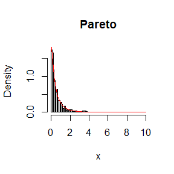

```r
set.seed(12345)
n <- 1000
u <- runif(n)
x <- 2*(1-u^(1/4))/u^(1/4)
hist(x, prob=TRUE, main = 'Pareto', xlim = c(0,10), breaks=100)
y <- seq(0, 10, .1)
lines(y, 64/(2+y)^5,lwd = 1.5, col = "red")
```

We can see that the empirical and theoretical distributions approximately agree.

## Homework-10.13

## Question1

Compute a Monte Carlo estimate of
$$\int_{0}^{\pi / 3} \sin t d t,$$
and compare your estimate with the exact value of the integral.

## Answer

We can straightly compute $\int_{0}^{\pi / 3} \sin t d t=-\left.\cos t\right|_{0} ^{\pi / 3}=\frac 1 2$. Thus the exact value is 0.5.

```r
set.seed(12345)
n <- 1e4
x <- runif(n, min = 0, max = pi/3)
theta.hat <- mean(sin(x))*pi/3
print(theta.hat)
```

```
## [1] 0.5009124
```

```r
print(1/2)
```

```
## [1] 0.5
```

We can see that the estimate is close to the exact value.

## Question2

Refer to Exercise $5.6 .$ Use a Monte Carlo simulation to estimate $\theta$ by the antithetic variate approach and by the simple Monte Carlo method. Compute an empirical estimate of the percent reduction in variance using the antithetic variate. Compare the result with the theoretical value from Exercise 5.6 .

## Answer

We first compute the theoretical percent reduction in variance as above:
$$\frac{Var(e^U)-Var(\frac{e^U+e^{1-U}}{2})}{Var(e^U)}=\frac{\frac 1 2 Var(e^U)-\frac 1 2Cov(e^U,e^{1-U})}{Var(e^U)}=\frac1 2 -\frac{e-(e-1)^2}{2(\frac{e^{2}-1}{2}-(e-1)^{2})}\doteq0.983835.$$

```r
set.seed(12345)
m <- 100000
U <- runif(m)
T1 <- exp(U)
T2 <- 1/2*exp(U)+1/2*exp(1-U)
mean(T1)
```

```
## [1] 1.719013
```

```r
mean(T2)
```

```
## [1] 1.71812
```

```r
(var(T1)-var(T2))/var(T1)
```

```
## [1] 0.9837697
```

We can see that empirical estimate of the percent reduction in variance is similiar to the theoretical.

## Question3

If $\hat{\theta}_{1}$ and $\hat{\theta}_{2}$ are unbiased estimators of $\theta,$ and $\hat{\theta}_{1}$ and $\hat{\theta}_{2}$ are antithetic, we derived that $c^{*}=1 / 2$ is the optimal constant that minimizes the variance of $\hat{\theta}_{c}=c \hat{\theta}_{1}+(1-c) \hat{\theta}_{2} .$ Derive $c^{*}$ for the general case. That is, if $\hat{\theta}_{1}$ and $\hat{\theta}_{2}$ are any two unbiased estimators of $\theta,$ find the value $c^{*}$ that minimizes the variance of the estimator $\hat{\theta}_{c}=c \hat{\theta}_{1}+(1-c) \hat{\theta}_{2}$ in equation $(5.11) .\left(c^{*}\right.$ will be a function of the variances and the covariance of the estimators.)

## Answer

Note that
$$Var(\hat{\theta}_c)=Var\left(\hat{\theta}_{1}-\hat{\theta}_{2}\right)c^{2} +2 Cov\left(\hat{\theta}_{2}, \hat{\theta}_{1}-\hat{\theta}_{2}\right)c +Var\left(\hat{\theta}_{2}\right).$$
Thus the quadratic function of $c$ arrives its minimum at
$$c^*=-\frac {Cov\left(\hat{\theta}_{2}, \hat{\theta}_{1}-\hat{\theta}_{2}\right)}{Var\left(\hat{\theta}_{1}-\hat{\theta}_{2}\right)}=\frac{Var(\hat{\theta}_{2})-Cov(\hat{\theta}_{1},\hat{\theta}_{2})}{Var(\hat{\theta}_{1})-2Cov(\hat{\theta}_{1},\hat{\theta}_{2})+Var(\hat{\theta}_{2})}.$$

## Homework-10.20

## Question1

Find two importance functions $f_{1}$ and $f_{2}$ that are supported on $(1, \infty)$ and are ‘close’ to
$$g(x)=\frac{x^{2}}{\sqrt{2 \pi}} e^{-x^{2} / 2}, \quad x>1,$$
Which of your two importance functions should produce the smaller variance in estimating
$$\int_{1}^{\infty} \frac{x^{2}}{\sqrt{2 \pi}} e^{-x^{2} / 2} d x,$$
by importance sampling? Explain.

## Answer

Let
$$\begin{aligned}
&f_{1}(x)=e^{1-x}, \quad 1<x<\infty,\\
&f_2(x)=4(1+x^2)^{-1}/\pi, \quad 1<x<\infty.
\end{aligned}$$
We will use inverse transform method to generate from $f_1(x)$ and $f_2(x)$.

```r
n <- 10000
set.seed(12345)
theta_hat <- numeric(2)
se <- numeric(2)
g <- function(x){
  x^2*exp(-x^2/2)/(sqrt(2*pi))* (x > 1)
}

u <- runif(n) #f1,inverse transform method
x <- 1-log(u)
fg <- g(x)/exp(1-x)
theta_hat[1] <- mean(fg)
se[1] <- sd(fg)

u <- runif(n) #f2,inverse transform method
x <- tan(pi/4*(u+1))
fg <- g(x)/(4/((1+x^2)*pi))
theta_hat[2] <- mean(fg)
se[2] <- sd(fg)

rbind(theta_hat, se)
```

```
##                [,1]      [,2]
## theta_hat 0.4020602 0.4038706
## se        0.1569158 0.3294217
```

Note that $f_1$ has smaller variance because $f_1$ has a more similiar shape to g. We will illustrate it below:

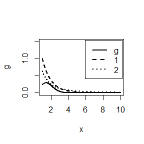

```r
x <- seq(1, 10, 0.01)
w <- 2
f1 <- exp(1-x)
f2 <- 4/((1+x^2)*pi)
g <- x^2/(sqrt(2*pi)) * exp(-x^2/2)

plot(x, g, type = "l", ylim=c(0,1.5), lwd = w)
lines(x, f1, lty = 2, lwd = w)
lines(x, f2, lty = 3, lwd = w)
legend("topright", legend = c("g", 1:2), lty = 1:3, lwd = w, inset = 0.02)
```

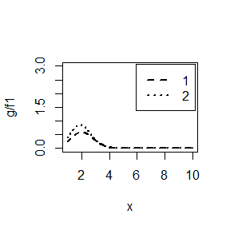

```r
plot(x, g/f1, type = "l", ylim = c(0,3), lwd = w, lty = 2)
lines(x, g/f2, lty = 3, lwd = w)
legend("topright", legend = c(1:2), lty = 2:3, lwd = w, inset = 0.02)
```

We can see from the picture that $f_1$ is more similiar to g.

## Question2

5.15 Obtain the stratified importance sampling estimate in Example 5.13 and compare it with the result of Example 5.10.

## Answer

```r
n <- 10000
k <- 5
r <- n/k
N <- 50
set.seed(12345)

T2 <- numeric(k)
est <- matrix(0, N, 2)
g<-function(x)exp(-x)/(1+x^2)*(x>0)*(x<1)
for (i in 1:N){
  u <- runif(n)
  x <- - log(1 - u * (1 - exp(-1)))
  fg <- g(x) / (exp(-x) / (1 - exp(-1)))
  est[i, 1] <- mean(fg)
  for(j in 1:k){
    u <- runif(n/k)
    t <- u * exp(-j/5)+(1 - u) * exp(-(j-1)/5)
    x <- - log(t)
    fg <- 5*g(x) / (exp(-x) / (exp(-(j-1)/5) - exp(-j/5)))
    T2[j] <- mean(fg)
  }
  est[i, 2] <- mean(T2)
}
theta_hat <- apply(est,2,mean)
se <- apply(est,2,sd)
rbind(theta_hat, se)
```

```
##                   [,1]         [,2]
## theta_hat 0.5247751830 0.5247930146
## se        0.0009004628 0.0001691092
```

We can see that the standard error in the stratified sampling is approximately $\frac 1 5$ of the importance sampling. The same as theoretical result that the standard error in the stratified sampling is reduced to $\frac 1 k$ of the importance sampling case.

## Question3

Suppose that $X_1,\cdots,X_n$ are a random sample from a from a lognormal distribution with unknown parameters. Construct a $95$% confidence interval for the parameter $\mu$. Use a Monte Carlo method to obtain an empirical estimate of the confidence level.

## Answer

```r
n <- 20
alpha <- .05
set.seed(1)
UCL <- replicate(1000, expr = {
  x <- rlnorm(n, 0, 2)
  sqrt(n)*mean(log(x))/sqrt(var(log(x)))/ qt(1-alpha/2,n-1)
  })
mean(abs(UCL) < 1)
```

```
## [1] 0.954
```

We can see that empirical estimate of the confidence level is 0.954, very close to the true value.

## Question4

Suppose a $95 \%$ symmetric $t$ -interval is applied to estimate a mean, but the sample data are non-normal. Then the probability that the confidence interval covers the mean is not necessarily equal to $0.95 .$ Use a Monte Carlo experiment to estimate the coverage probability of the $t$ -interval for random samples of $\chi^{2}(2)$ data with sample size $n=20 .$ Compare your $t$ -interval results with the simulation results in Example $6.4 .$ (The $t$ -interval should be more robust to departures from normality than the interval for variance.)

## Answer

We generate the empirical estimate of the confidence level the same as question $3$ and example $6.4$.

```r
n <- 20
alpha <- .05
UCL <- replicate(1000, expr = {
  x <- rchisq(n, df = 2)
  sqrt(n)*(mean(x)-2)/sqrt(var(x))/ qt(1-alpha/2,n-1)
  })
mean(abs(UCL) < 1)
```

```
## [1] 0.939
```

```r
UCL <- replicate(1000, expr = {
  x <- rchisq(n, df = 2)
  (n-1)*var(x)/qchisq(alpha,n-1)
  })
mean(UCL > 4)
```

```
## [1] 0.794
```

We can see that coverage probability of the $t$ -interval is much more close to 0.95 than the interval of the variance. This proves that $t$ -interval is more robust to departures from normality than the interval for variance.

## Homework-10.27

## Question1

Estimate the power of the skewness test of normality against symmetric Beta($\alpha,\alpha$) distributions and comment on the results. Are the results different for heavy-tailed symmetric alternatives such as $t(\nu)$?

## Answer

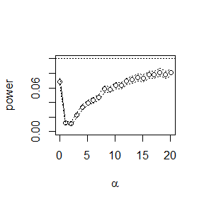

```r
sk <- function(x) {
#computes the sample skewness coeff.
xbar <- mean(x)
m3 <- mean((x - xbar)^3)
m2 <- mean((x - xbar)^2)
return( m3 / m2^1.5 )
}

set.seed(12345)
a <- .1              #significance level
n <- 30
m <- 3000
alpha <- seq(.1, 20.1, 1)
N <- length(alpha)
pwr_Beta <- numeric(N)
#critical value for the skewness test
cv <- qnorm(1 - a / 2, 0, sqrt(6 * (n - 2) / ((n + 1) * (n + 3))))

for (i in 1:N) {     #for each alpha
  sktests_Beta <- numeric(m)
  for (j in 1:m) {   #for each replicate
    x_Beta <- rbeta(n, alpha[i], alpha[i])
    sktests_Beta[j] <- as.integer(abs(sk(x_Beta)) >= cv)
  }
  pwr_Beta[i] <- mean(sktests_Beta)
}
#plot power vs alpha
plot(alpha, pwr_Beta, xlab = bquote(alpha), ylab = "power",
      type = "b", ylim = c(0, 0.1))
abline(h = .1, lty = 3)                         #significance level
se_Beta <- sqrt(pwr_Beta * (1 - pwr_Beta) / m)  #standard error
#plot confidence interval
lines(alpha, pwr_Beta + se_Beta, lty = 3)
lines(alpha, pwr_Beta - se_Beta, lty = 3)
```

The empirical power curve vs $\alpha$ is shown above. Note that the power curve is below the horizontal line corresponding to a=0.10. This is beacause the skewness of points generated from symmetric beta is always near 0. That makes the test inefficient in the symmetric beta circumstance.

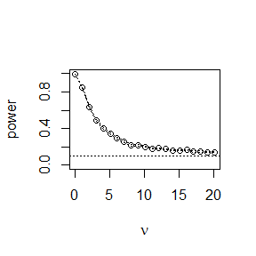

```r
nu <- seq(.1, 20.1, 1)
N2 <- length(nu)
pwr_t <- numeric(N2)

for (i in 1:N2) {        #for each nu
  skt_t <- numeric(m)
  for (j in 1:m) {       #for each replicate
    x_t <- rt(n, nu[i])
    skt_t[j] <- as.integer(abs(sk(x_t)) >= cv)
  }
  pwr_t[i] <- mean(skt_t)   #power
}

#plot power vs nu
plot(nu, pwr_t, xlab = bquote(nu), ylab = "power",
     type = "b", ylim = c(0, 1))
abline(h = .1, lty = 3)                #significance level
se_t <- sqrt(pwr_t * (1 - pwr_t) / m)  #standard error
#plot confidence interval
lines(nu, pwr_t + se_t, lty = 3)
lines(nu, pwr_t - se_t, lty = 3)
```

The empirical power curve vs $\nu$ is shown above. Note that the power curve is above the horizontal line corresponding to a=0.10 and power gets smaller as $\nu$ gets bigger. This is because the t-distribution is similiar to normal distribution as nu gets big. Therefore, it is difficult to distinguish one from another and makes the power small. The power is big with small $\nu$.

All in all, it illustrates that the skewness test of normality is inefficient to symmetric beta and t-distribution with large $\nu$. We can only use the skewness test of normality to detect t-distribution with small $\nu$.

## Question2

Refer to Example 6.16. Repeat the simulation, but also compute the $F$ test of equal variance, at significance level $\hat{\alpha}\doteq0.055$. Compare the power of the Count Five test and $F$ test for small, medium, and large sample sizes. (Recall that the $F$ test is not applicable for non-normal distributions.)

## Answer

```r
sigma1 <- 1
sigma2 <- 1.5
m <- 10000

count5test <- function(x, y) {
  X <- x - mean(x)
  Y <- y - mean(y)
  outx <- sum(X > max(Y)) + sum(X < min(Y))
  outy <- sum(Y > max(X)) + sum(Y < min(X))
  return(as.integer(max(c(outx, outy)) > 5))
}

power_count <- function(m,n,sigma1,sigma2){
  tests <- replicate(m, expr = {
  x <- rnorm(n, 0, sigma1)
  y <- rnorm(n, 0, sigma2)
  count5test(x, y)
  } )
  return(mean(tests))
}

power_f <- function(m,n,sigma1,sigma2){
  tests <- replicate(m, expr = {
  x <- rnorm(n, 0, sigma1)
  y <- rnorm(n, 0, sigma2)
  return(as.integer(var.test(x,y,conf.level=0.945)$p.value<0.055))
  } )
  return(mean(tests))
}

n <- c(20, 100, 500)
k = length(n)
power_1 = numeric(k)
power_2 = numeric(k)

for(i in 1:k){
  power_1[i] <- power_count(m,n[i],sigma1,sigma2)
  power_2[i] <- power_f(m,n[i],sigma1,sigma2)
}
df<-data.frame(power_1, power_2)
names(df) <- c("Count Five test","F-test")
row.names(df) <- c("n=20", "n=100", "n=500")
knitr::kable(df)
```

|  | Count Five test | F-test |
| --- | --- | --- |
| n=20 | 0.3140 | 0.4197 |
| n=100 | 0.8493 | 0.9828 |
| n=500 | 0.9917 | 1.0000 |

We can see that the power of both tests increase as n gets bigger which means that both methods are asmyptotic efficient. And the power of F-test is better than Count Five test in all the circumstances.

## Question3

Repeat Examples 6.8 and 6.10 for Mardia’s multivariate skewness test. Mardia proposed tests of multivariate normality based on multivariate generalizations of skewness and kurtosis. If $X$ and $Y$ are iid, the multivariate population skewness $\beta_{1, d}$ is defined by Mardia as
$$\beta_{1, d}=E\left[(X-\mu)^{T} \Sigma^{-1}(Y-\mu)\right]^{3}.$$
Under normality, $\beta_{1, d}=0 .$ The multivariate skewness statistic is
$$b_{1, d}=\frac{1}{n^{2}} \sum_{i, j=1}^{n}\left(\left(X_{i}-\bar{X}\right)^{T} \widehat{\Sigma}^{-1}\left(X_{j}-\bar{X}\right)\right)^{3}.$$
where $\hat{\Sigma}$ is the maximum likelihood estimator of covariance. Large values of $b_{1, d}$ are significant. The asymptotic distribution of $n b_{1, d} / 6$ is chisquared with $d(d+1)(d+2) / 6$ degrees of freedom.

## Answer

```r
set.seed(1234)
m <- 1000
library(MASS)
#compute the skewness function
sk2 <- function(X) {
        k <- nrow(X)
        Y <- matrix(rep(colMeans(X),k), nrow=k, byrow=TRUE)     #colmean
        Sigma <- t(X-Y)%*%(X-Y)/k                               #covariance
        b <- sum(((X-Y)%*%solve(Sigma)%*%t(X-Y))^3)
        return(b/k^2)
}
sktests=function(n,cv,d){
  tests <- replicate(m, expr = {                #tests
          x=mvrnorm(n,rep(0,d),diag(d))         #generation
          return(as.integer(sk2(x)>=cv))
          } )
mean(tests)
}
f <- function(d){
         n <- c(10,20,30,50,100,500)
         #critical value for the skewness test
         cv <- qchisq(0.95, d*(d+1)*(d+2)/6)*6/n
         p.reject <- numeric(length(n))
        for(i in 1:length(n)){
             p.reject[i] <- sktests(n[i],cv[i],d)
        }
 p.reject          #percent of reject
}
df2 <- data.frame(f(1), f(2))
names(df2) <- c("d=1","d=2")
row.names(df2) <- c("n=10", "n=20", "n=30", "n=50", "n=100", "n=500")
knitr::kable(df2)
```

|  | d=1 | d=2 |
| --- | --- | --- |
| n=10 | 0.013 | 0.005 |
| n=20 | 0.027 | 0.022 |
| n=30 | 0.033 | 0.034 |
| n=50 | 0.038 | 0.035 |
| n=100 | 0.040 | 0.045 |
| n=500 | 0.052 | 0.063 |

From above we give the similiar result to exmaple 6.8 in dimension 1 and 2.

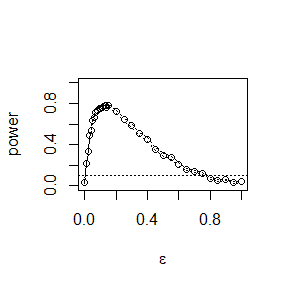

```r
alpha=0.1            #significance level
g <- function(d,n){
    epsilon <- c(seq(0, .15, .01), seq(.15, 1, .05))
    N <- length(epsilon)
    pwr <- numeric(N)
    #critical value for the skewness test
    cv <- qchisq(.95, d*(d+1)*(d+2)/6)*6/n
    for (j in 1:N) {              #for each epsilon
        e <- epsilon[j]
        sktests <- numeric(m)
        for (i in 1:m) {           #for each replicate
                x <- matrix(0, nrow = n, ncol = d)
                for(k in 1:n){
                   sigma <- sample(c(1, 10), replace = TRUE,
                                size = 1, prob = c(1-e, e))
                   x[k,] <- mvrnorm(1, rep(0, d), (sigma^2)*diag(d))
                }
              sktests[i] <- as.integer(sk2(x)>=cv)
        }
        pwr[j] <- mean(sktests)      #power
    }
     #plot power vs epsilon
     plot(epsilon, pwr,xlab = bquote(epsilon), ylab = "power",
          type = "b", ylim = c(0,1))
     abline(h = .1, lty = 3)       #significance level
     se <- sqrt(pwr * (1-pwr) / m) #standard errors
     #plot confidence interval
     lines(epsilon, pwr+se, lty = 3)
     lines(epsilon, pwr-se, lty = 3)
}
g(1,30) #d=1,n=30
```

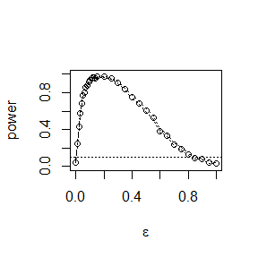

```r
g(2,30) #d=2,n=30
```

From above we plot the similiar picture to exmaple 6.10 in dimension 1 and 2.

## Question4

If we obtain the powers for two methods under a particular simulation setting with 10,000 experiments: say, 0.651 for one method and 0.676 for another method. Can we say the powers are different at 0.05 level?

$(1)$ What is the corresponding hypothesis test problem?

$(2)$ What test should we use? Z-test, two-sample t-test, paired-t test or McNemar test?

$(3)$ What information is needed to test your hypothesis?

## Answer

$(1)$ Let the tests be $T_1$ and $T_2$. Denote the power of $T_i$ as $\pi_i,$ $i=1,2$. Thus, the corresponding hypothesis test problem can be described as:$H_0:\pi_1=\pi_2\leftrightarrow H_a:\pi_1\neq\pi_2.$

$(2)$ As a matter of fact, Z-test, paired-t test and McNemar test all can be used for test except two-sample t-test. This is because two-sample t-test requires that the data of two samples are statistically independent and this is not satisfied as we use the same simulation setting.

$(3)$ We need to know that in each simulation the null hypothesis was rejected or not for the two tests.

## Homework-11.03

## Question1

Compute a jackknife estimate of the bias and the standard error of the correlation statistic in Example 7.2.

## Answer

```r
data(law, package = "bootstrap") #import data
n <- nrow(law)
x <- law$LSAT
y <- law$GPA
theta_hat <- cor(x,y)
#compute the leave-one-out estimates
theta_jack <- rep(0, n)
for (i in 1:n)
  theta_jack[i] <- cor(x[-i],y[-i])
bias <- (n - 1) * (mean(theta_jack) - theta_hat)
se <- (n - 1) * sqrt(var(theta_jack) / n)
df <- data.frame(theta_hat, bias, se)
knitr::kable(df)
```

| theta_hat | bias | se |
| --- | --- | --- |
| 0.7763745 | -0.0064736 | 0.1425186 |

## Question2

Refer to Exercise 7.4. Compute $95%$ bootstrap confidence intervals for the mean time between failures $1/\lambda$ by the standard normal, basic, percentile, and BCa methods. Compare the intervals and explain why they may differ.

## Answer

Note that mle of $1/\lambda$ is $\frac{\sum_{i=1}^{n}x_n}n$ which is the sample mean.

```r
set.seed(12345)
options(warn = -1)
library(boot)
B <- 2000                                                         #bootstrap number
stat <- function(dat, index){mean(dat[index])}                    #function
bootstrap_result <- boot(data = aircondit$hours, stat, R = B)     #boot result
boot.ci(bootstrap_result, conf = 0.95, type = c("norm", "basic", "perc", "bca"))
```

```
## BOOTSTRAP CONFIDENCE INTERVAL CALCULATIONS
## Based on 2000 bootstrap replicates
##
## CALL :
## boot.ci(boot.out = bootstrap_result, conf = 0.95, type = c("norm",
##     "basic", "perc", "bca"))
##
## Intervals :
## Level      Normal              Basic
## 95%   ( 34.4, 181.4 )   ( 24.3, 170.1 )
##
## Level     Percentile            BCa
## 95%   ( 46.1, 191.9 )   ( 55.6, 224.7 )
## Calculations and Intervals on Original Scale
## Some BCa intervals may be unstable
```

We can see that the interval of bca method is larger than the three methods. This is because the interval tends to be too narrow for small n with normal and basic methods.

We get a warning message that BCa intervals may be unstable. This is because the accuracy of the bias and acceleration terms require a large number of bootstrap samples and this can be computationally intensive.

## Question3

Refer to Exercise 7.7. Obtain the jackknife estimates of bias and standard error of $\hat{\theta}$.

## Answer

```r
data(scor, package = "bootstrap") #import data
n <- nrow(scor)
lambda_hat <- eigen((n-1)*cov(scor)/n)$values
theta_hat <- lambda_hat[1]/sum(lambda_hat)
theta_j <- rep(0, n)
for (i in 1:n) {
  x <- scor [-i,]
  m <- n-1
  lambda <- eigen((m-1)*cov(x)/m)$values
  theta_jack[i] <- lambda[1] / sum(lambda)
  }
bias <- (n - 1) * (mean(theta_jack) - theta_hat)
se <- (n - 1) * sqrt(var(theta_jack) / n)
df2 <- data.frame(theta_hat, bias, se)
knitr::kable(df2)
```

| theta_hat | bias | se |
| --- | --- | --- |
| 0.619115 | 0.0010691 | 0.0495523 |

## Question4

In Example 7.18, leave-one-out (n-fold) cross validation was used to select the best fitting model. Use leave-two-out cross validation to compare the models.

## Answer

```r
data(ironslag, package = "DAAG")
magnetic <- ironslag$magnetic
chemical <- ironslag$chemical
n <- nrow(ironslag)
e1 <- e2 <- e3 <- e4 <- matrix(0,n,n)
# for n-fold cross validation
# fit models on leave-two-out samples
for (k in 1:n) {
  for(l in 1:n){
    y <- magnetic[c(-k,-l)]
    x <- chemical[c(-k,-l)]

    J1 <- lm(y ~ x)
    yhat11 <- J1$coef[1] + J1$coef[2] * chemical[k]
    yhat12 <- J1$coef[1] + J1$coef[2] * chemical[l]
    e1[k,l] <- ((magnetic[k] - yhat11)^2 + (magnetic[l] - yhat12)^2)/2       #mean error

    J2 <- lm(y ~ x + I(x^2))
    yhat21 <- J2$coef[1] + J2$coef[2] * chemical[k] + J2$coef[3] * chemical[k]^2
    yhat22 <- J2$coef[1] + J2$coef[2] * chemical[l] + J2$coef[3] * chemical[l]^2
    e2[k,l] <- ((magnetic[k] - yhat21)^2 + (magnetic[l] - yhat22)^2)/2      #mean error

    J3 <- lm(log(y) ~ x)
    logyhat31 <- J3$coef[1] + J3$coef[2] * chemical[k]
    logyhat32 <- J3$coef[1] + J3$coef[2] * chemical[l]
    yhat31 <- exp(logyhat31)
    yhat32 <- exp(logyhat32)
    e3[k,l] <- ((magnetic[k] - yhat31)^2 + (magnetic[l] - yhat32)^2)/2       #mean error

    J4 <- lm(log(y) ~ log(x))
    logyhat41 <- J4$coef[1] + J4$coef[2] * log(chemical[k])
    logyhat42 <- J4$coef[1] + J4$coef[2] * log(chemical[l])
    yhat41 <- exp(logyhat41)
    yhat42 <- exp(logyhat42)
    e4[k,l] <- ((magnetic[k] - yhat41)^2 + (magnetic[l] - yhat42)^2)/2       #mean error
  }
}
df3 <- data.frame(mean(e1), mean(e2), mean(e3), mean(e4))
names(df3)=c("mean1", "mean2", "mean3", "mean4")
knitr::kable(df3)
```

| mean1 | mean2 | mean3 | mean4 |
| --- | --- | --- | --- |
| 19.57197 | 17.86985 | 18.45467 | 20.46693 |

According to the predction error criterion, Model 2 would be the best fit for the data. Below is the fitted regression equation and residual plots.

```r
L2 <- lm(magnetic ~ chemical + I(chemical^2))
L2
```

```
##
## Call:
## lm(formula = magnetic ~ chemical + I(chemical^2))
##
## Coefficients:
##   (Intercept)       chemical  I(chemical^2)
##      24.49262       -1.39334        0.05452
```

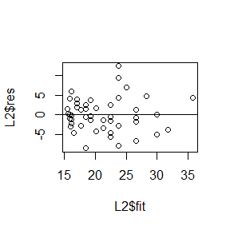

```r
plot(L2$fit, L2$res)            #residuals vs fitted values
abline(0, 0)                    #reference line
```

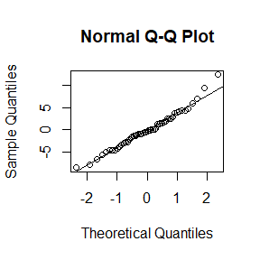

```r
qqnorm(L2$res)                  #qq plot
qqline(L2$res)
```

## Homework-11.10

## Question1

The Count 5 test for equal variances in Section 6.4 is based on the maximum number of extreme points. Example 6.15 shows that the Count 5 criterion is not applicable for unequal sample sizes. Implement a permutation test for equal variance based on the maximum number of extreme points that applies when sample sizes are not necessarily equal.